# Extracting Data from Raster

Cole Tanigawa-Lau

Raster files divide data into congruent cells spread over space, creating a grid of cells with continuous values, like pixels of an image. The precision (or resolution) of the raster data depends on the size of these grid cells. For a given area, smaller cells means more data, and like any other high-resolution image, raster files are often very large. The `raster` package is able to process raster files without loading them into memory by performing functions on chunks of the data at a time.

Loading a raster into an `R` object stores only information about the raster file, keeping your RAM available for other things.

```r
library(sp)
library(rgdal)
```

```r
library(maptools)
library(raster)

pop10adj <- raster("~/Google Drive/pak/PAK-POP/popmap10adj.tif")
object.size(pop10adj)
```

```
## 11672 bytes
```

```r
pop10adj
```

```
## class       : RasterLayer
## dimensions  : 16076, 20175, 324333300  (nrow, ncol, ncell)
## resolution  : 0.0008333, 0.0008333  (x, y)
## extent      : 60.87816, 77.68999, 23.69404, 37.09018  (xmin, xmax, ymin, ymax)
## coord. ref. : +proj=longlat +datum=WGS84 +no_defs +ellps=WGS84 +towgs84=0,0,0
## data source : /Users/netid/Google Drive/pak/PAK-POP/popmap10adj.tif
## names       : popmap10adj
## values      : 0, 7312.038  (min, max)
```

Shapefiles store geographic information in vector format as points, lines or polygons. The `maptools`, `rgeos`, and `rgdal` packages provide a host of functions useful for reading, creating, manipulating, and analyzing shapefiles.

```r
const <- readShapeSpatial("~/Google Drive/pak/national-constituency-boundary/National_Constituency_Boundary.shp")
```

The structure of shapefiles stored in `R` is fairly complex (try printing `str(const)` . . .), and for a full description you should check out the `sp` [package vignette](https://cran.r-project.org/web/packages/sp/vignettes/intro_sp.pdf). To put it simply, these objects consist of features, or shapes, with data about them stored in different slots. You index these slots using `@`. The most important slots (for this exercise and for most of the work you'll be doing) are `@proj4string`, which defines the object’s [geographic projection](https://en.wikipedia.org/wiki/Map_projection), and `@data`, which holds a data frame object. Each row of this data frame corresponds to a feature in the spatial geometry. So in this example, every row contains data about a single constituency in Pakistan. You can index these spatial geometries as you would a data frame.

```r
head(const@data)
```

```
##   Id NA_Cons WON         District Province
## 0  0   NA-36  ID  MOHAMDAN AGENCY     FATA
## 1  0   NA-37  ID     KURAM AGENCY     FATA
## 2  0   NA-38  ID     KURAM AGENCY     FATA
## 3  0   NA-39  ID   ORAKZAI AGENCY     FATA
## 4  0   NA-40  ID NORTH WAZIRASTAN     FATA
## 5  0   NA-41  ID SOUTH WAZIRASTAN     FATA
```

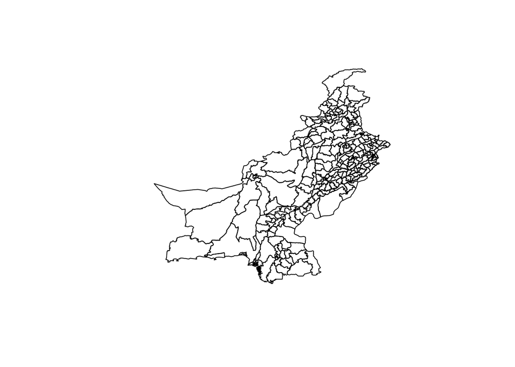

```r
plot(const)
```

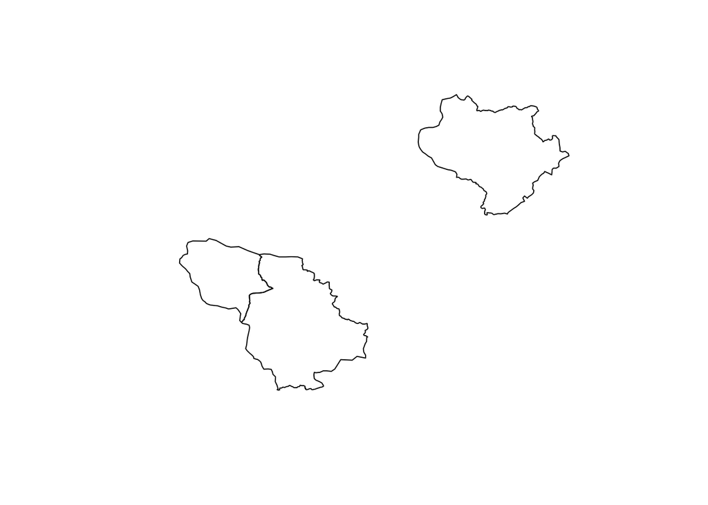

```r
plot(const[1:3, ])
```

```r
const
```

```
## class       : SpatialPolygonsDataFrame
## features    : 273
## extent      : 60.89194, 75.38139, 23.70307, 36.91602  (xmin, xmax, ymin, ymax)
## coord. ref. : NA
## variables   : 5
## names       : Id, NA_Cons,          WON,               District,    Province
## min values  :  0,    NA-1,          ANP,             ABBOTTABAD, BALOCHISTAN
## max values  :  0,   NA-99, PPP(SHERPAO), ZOB AN KILHA SIAFULLAH,       SINDH
```

Notice that the coordinate reference system above is currently `NA`. Unfortunately, `readShapeSpatial()` will not look into the associated projection file. We need to set the projection manually (or use the slower `readOGR()` function from `rgdal`) before using `const` in conjunction with any other spatial object. You can find out what projection to use by opening the `.prj` file in any text editor. Whenever you perform a function on two spatial objects, be sure they are in the same projection!

```r
proj4string(const) <- "+proj=longlat +datum=WGS84 +no_defs +ellps=WGS84 +towgs84=0,0,0"
identicalCRS(pop10adj, const)
```

```
## [1] TRUE
```

```r
pop10adj_const <- extract(x = pop10adj, y = const, fun = mean, na.rm = TRUE)
const@data <- data.frame(const@data, pop_10adj = pop10adj_const, log_pop10adj = log1p(pop10adj_const))

saveRDS(const, "~/Google Drive/pak/const2/const2.rds")
writeSpatialShape(const, "~/Google Drive/pak/const2/const2.shp")
```

To repeat this process for multiple raster files, the most straightforward method would be to write code using the `extract()` function for each raster, then running all of those lines overnight. Alternatively, you could build a `RasterStack` or `RasterBrick` object and run `extract()` just once. If you want to check that your code worked, the easiest way might be to plot the data on a map and check that it corresponds to what you know about Pakistan’s population density. I’ll use the logged population density variable so that we can see some variation. For a more complete introduction to visualizing shapefiles with, check out the [tidyverse wiki](https://github.com/tidyverse/ggplot2/wiki/plotting-polygon-sh…) on GitHub or Robin Lovelace’s lengthier [tutorial](https://github.com/Robinlovelace/Creating-maps-in-R/blob/master/intro-spatial.Rmd).

```r
library(dplyr)
```

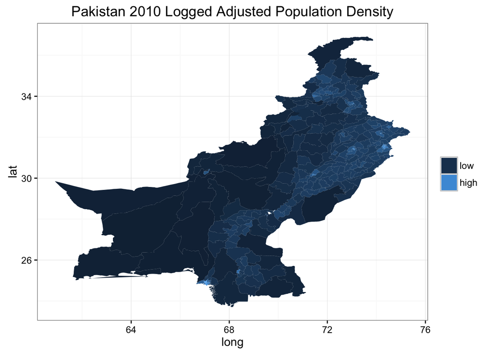

```r
library(broom)
library(ggplot2)

const$id <- rownames(const@data)
const_tidy <- tidy(const)
# const_tidy$Id <- as.numeric(const_tidy$id) # Create new "Id" column to join by
const_tidy2 <- left_join(const_tidy, const@data)
ggplot(const_tidy2, aes(x = long, y = lat)) + geom_polygon(aes(fill = log_pop10adj, group = id)) +
  scale_fill_continuous(guide = guide_legend(title = NULL),
                        breaks = c(1, 5), labels = c("low", "high")) +
  ggtitle("Pakistan 2010 Logged Adjusted Population Density") + theme_bw() # Remove axis ticks
```